# Guía 1_ Entregable

**Proyecto 1 – Relación Minutos Ingreso**  
Integrantes del Grupo: Germán Macias y Mauricio Herreralientes.

- totrev: Ingresos del cliente.
- totmou: Total de minutos usados por el cliente.
- creditcd: Indicador de tarjeta crédito.
- eqpdays: Número de días (antigüedad) del equipo actual..

Es importante mencionar que la empresa contiene una gran cantidad de clientes y hacer el análisis uno a uno no es lo óptimo. Con ayuda de la programación y el análisis de datos, se logrará llegar a conclusiones rápidas y acertadas para encontrar relaciones que a simple vista no son tenidas en cuenes. En Python realice una exploración descriptiva de los datos que incluya:

- Descripción de las variables de la base.
- Tratamiento de valores nulos, si aplica.
- Crear algunos gráficos que evidencien la relación entre minutos y el ingreso de los clientes.

```python
# Importar las librerias necesarias
import pandas as pd
import matplotlib.pyplot as plt
import seaborn as sns
import numpy as np
from sklearn import linear_model
from sklearn import model_selection
from sklearn.metrics import classification_report
from sklearn.metrics import confusion_matrix
from sklearn.metrics import accuracy_score
from sklearn.model_selection import train_test_split
from sklearn.linear_model import LogisticRegression
from sklearn.linear_model import LinearRegression

# Leer el documento 'Credito_dias.txt' con el separador ´,´
df = pd.read_csv('Credito_dias.txt', sep=',')
```

```python
# Mostrar las primeras filas e información básica sobre el conjunto de datos
print(df.head())
print("\nInformation del Dataset")
print(df.info())
```

```
    totmou   totrev creditcd  eqpdays  Customer_ID
0   7269.0   906.58        Y      371      1082423
1  13552.0  1172.25        N       83      1069232
2   4152.0   577.39        Y      675      1031705
3   1863.0   294.26        Y      218      1089806
4   4155.0   433.16        N      222      1076695

Information del Dataset
<class 'pandas.core.frame.DataFrame'>
RangeIndex: 10000 entries, 0 to 9999
Data columns (total 5 columns):
 #   Column       Non-Null Count  Dtype
---  ------       --------------  -----
 0   totmou       10000 non-null  float64
 1   totrev       10000 non-null  float64
 2   creditcd     9848 non-null   object
 3   eqpdays      10000 non-null  int64
 4   Customer_ID  10000 non-null  int64
dtypes: float64(2), int64(2), object(1)
memory usage: 390.8+ KB
None
```

**1. Descripción de las variables de la base**  
El conjunto de datos contiene 10,000 entradas con 5 variables:

- totmou: Total de minutos de uso (numérico)
- totrev: Ingreso total (numérico)
- creditcd: Estado de la tarjeta de crédito (categórico: 'Y' o 'N')
- eqpdays: Días de equipo (numérico)
- Customer_ID: Identificador único del cliente (numérico)

Convertir el identificador unico del cliente (Customer_ID) en cadena de texto

```python
# Convert 'Customer_ID' to string in the original DataFrame
df['Customer_ID'] = df['Customer_ID'].astype(str)
```

```python
print("\nInformation del Dataset Normalizado")
print(df.info())
```

```
Information del Dataset Normalizado
<class 'pandas.core.frame.DataFrame'>
RangeIndex: 10000 entries, 0 to 9999
Data columns (total 5 columns):
 #   Column       Non-Null Count  Dtype
---  ------       --------------  -----
 0   totmou       10000 non-null  float64
 1   totrev       10000 non-null  float64
 2   creditcd     9848 non-null   object
 3   eqpdays      10000 non-null  int64
 4   Customer_ID  10000 non-null  object
dtypes: float64(2), int64(1), object(2)
memory usage: 390.8+ KB
None
```

```python
# Mostrar estadísticas resumidas
print("\nResumen estadístico:")
print(df.describe())
```

```
Resumen estadístico:
              totmou        totrev       eqpdays
count   10000.000000  10000.000000  10000.000000
mean     7692.804866   1042.133807    386.794500
std      8657.917883    857.144895    252.720196
min         0.000000     11.100000     -5.000000
25%      2576.000000    526.787500    210.000000
50%      5262.000000    820.235000    338.000000
75%      9823.250000   1272.975000    522.000000
max    163264.176700  13426.600000   1823.000000
```

```python
# Comprobación de valores nulos
print("\nNull Values:")
print(df.isnull().sum())
```

```
Null Values:
totmou           0
totrev           0
creditcd       152
eqpdays          0
Customer_ID      0
dtype: int64
```

**2. Tratamiento de valores nulos**  
Se encontraron 152 valores nulos en la columna 'creditcd'. Estos valores nulos podrían necesitar tratamiento, como imputación o eliminación. Como se carece información adicional del contexto, se hará tratamiento de eliminación.

```python
# Eliminar registros con valores nulos
df_clean = df.dropna()
```

```python
# Comprobación de valores nulos despues de la eliminación
print("\nNull Values:")
print(df_clean.isnull().sum())
```

```
Null Values:
totmou         0
totrev         0
creditcd       0
eqpdays        0
Customer_ID    0
dtype: int64
```

```python
# Comparación del tamaño de los dataframe antes y despues de la eliminación de los registros con valores nulos
print("\nTamaño del DataFrame original:", df.shape)
print("Tamaño del DataFrame sin valores nulos:", df_clean.shape)
```

```
Tamaño del DataFrame original: (10000, 5)
Tamaño del DataFrame sin valores nulos: (9848, 5)
```

Los días de equipo (eqpdays) tienen algunos valores negativos, lo cual podría requerir una investigación adicional.

```python
# Crear un nuevo DataFrame con los valores de 'eqpdays' iguales o menores que 0
df_eqpdays_zero_or_less = df_clean[df_clean['eqpdays'] < 0].copy()
```

```python
# Contar la cantidad de registros en el nuevo DataFrame 'df_eqpdays_zero_or_less'
num_registros = len(df_eqpdays_zero_or_less)
print(f"\
Cantidad de registros con 'eqpdays' iguales o menores que 0: {num_registros}")
```

```
Cantidad de registros con 'eqpdays' iguales o menores que 0: 18
```

```python
# Mostar la cantidad de registros del DataFrame 'df_eqpdays_zero_or_less'
print(df_eqpdays_zero_or_less)
```

```
        totmou   totrev creditcd  eqpdays Customer_ID
264   12032.00  1544.09        Y       -3     1039062
831   33119.00  2023.26        N       -5     1040523
904    7147.00  1224.90        N       -4     1090059
950    5458.00   579.42        Y       -4     1082715
1450  35504.00  1304.23        Y       -3     1033477
1483  25275.00  3854.24        Y       -3     1004135
2727  32410.00  2662.25        Y       -1     1038414
3271  15240.00  1644.32        Y       -1     1035737
3289   6024.00   494.19        Y       -1     1095461
3646  23448.00  1185.93        Y       -1     1091198
4125   8812.00  1338.52        Y       -3     1032266
5009  25778.00  1658.19        Y       -1     1014327
5764  10476.00  1500.80        N       -2     1029317
6021  11565.00  2338.79        Y       -5     1007977
6459   6426.00   993.69        N       -4     1047077
6678   4477.00   836.69        Y       -1     1042189
7001  17186.00  1573.37        Y       -4     1016435
8181  25239.06  4092.76        Y       -1     1001372
```

```python
# Mostrar un resumen estadístico del DataFrame'df_eqpdays_zero_or_less'
print("\
Resumen estad\u00edstico del DataFrame 'df_eqpdays_zero_or_less':")
print(df_eqpdays_zero_or_less.describe())
```

```
Resumen estadístico del DataFrame 'df_eqpdays_zero_or_less':
             totmou       totrev    eqpdays
count     18.000000    18.000000  18.000000
mean   16978.670000  1713.868889  -2.611111
std    10518.983202   988.673499   1.500545
min     4477.000000   494.190000  -5.000000
25%     7563.250000  1195.672500  -4.000000
50%    13636.000000  1522.445000  -3.000000
75%    25266.015000  1931.992500  -1.000000
max    35504.000000  4092.760000  -1.000000
```

**3. Relación entre minutos y el ingreso de los clientes**  
Se han creado tres gráficos para visualizar las relaciones en los datos:

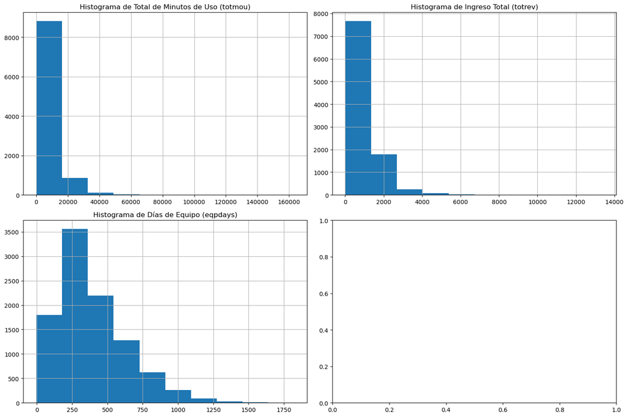

```python
# Histogramas para las tres variables numericas
fig, axes = plt.subplots(2, 2, figsize=(15, 10))
df_clean['totmou'].hist(ax=axes[0, 0])
axes[0, 0].set_title('Histograma de Total de Minutos de Uso (totmou)')
df_clean['totrev'].hist(ax=axes[0, 1])
axes[0, 1].set_title('Histograma de Ingreso Total (totrev)')
df_clean['eqpdays'].hist(ax=axes[1, 0])
axes[1, 0].set_title('Histograma de Días de Equipo (eqpdays)')
plt.tight_layout()
plt.show()
```

a. Gráfico de dispersión entre 'totmou' (minutos) y 'totrev' (ingreso):

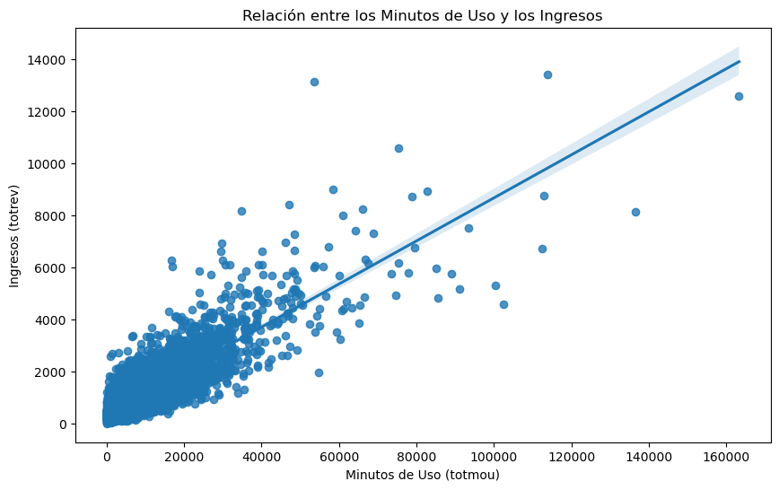

```python
# Crear gráfico para mostrar la relación entre los Minutos de Uso (totmou) y los Ingresos (totrev)
plt.figure(figsize=(10, 6))
sns.regplot(x='totmou', y='totrev', data=df_clean)
plt.title('Relación entre los Minutos de Uso y los Ingresos')
plt.xlabel('Minutos de Uso (totmou)')
plt.ylabel('Ingresos (totrev)')
plt.show()
#plt.savefig('minutos_vs_ingresos_scatter.png')
plt.close()
```

Este gráfico muestra una fuerte relación positiva entre el total de minutos de uso y el ingreso total. A medida que aumentan los minutos de uso, el ingreso tiende a aumentar también. Sin embargo, se observa cierta dispersión, lo que sugiere que otros factores también influyen en el ingreso.

```python
# Filtrar el DataFrame para incluir sólo las filas donde 'totmou' es menor o igual a 6000
df_filtered = df_clean[df_clean['totmou'] < 6500]

# Mostrar el número de registros en el DataFrame filtrado
num_filtered_records = df_filtered.shape[0]
print(f"Number of records in the filtered DataFrame: {num_filtered_records}")
```

```
Number of records in the filtered DataFrame: 5783
```

```python
# Mostrar las primeras filas del DataFrame filtrado
print(df_filtered.head())
```

```
   totmou  totrev creditcd  eqpdays Customer_ID
2  4152.0  577.39        Y      675     1031705
3  1863.0  294.26        Y      218     1089806
4  4155.0  433.16        N      222     1076695
5  5441.0  578.80        Y       68     1091652
7  4395.0  668.23        N      333     1088967
```

```python
# Mostrar un resumen estadístico del DataFrame'df_filtered'
print("\
Resumen estadístico del DataFrame 'df_filtered':")
print(df_filtered.describe())
```

```
Resumen estadístico del DataFrame 'df_filtered':
            totmou       totrev      eqpdays
count  5783.000000  5783.000000  5783.000000
mean   3095.608734   658.510303   408.245547
std    1764.553368   331.616887   252.111150
min       0.000000    11.100000    -4.000000
25%    1636.500000   420.945000   233.500000
50%    2982.000000   600.270000   350.000000
75%    4519.000000   836.730000   547.500000
max    6498.000000  2784.610000  1823.000000
```

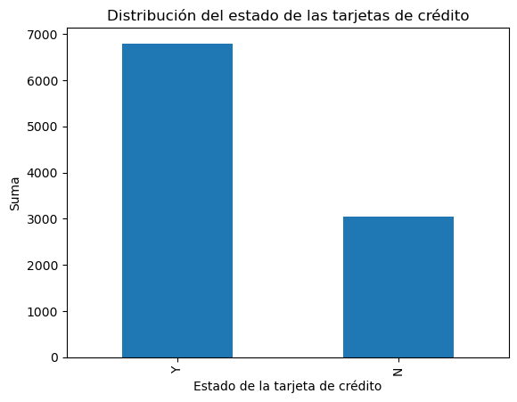

```python
# Diagrama de barras para variable categórica (creditcd)
df_clean['creditcd'].value_counts().plot(kind='bar')
plt.title('Distribución del estado de las tarjetas de crédito')
plt.xlabel('Estado de la tarjeta de crédito')
plt.ylabel('Suma')
plt.show()
```

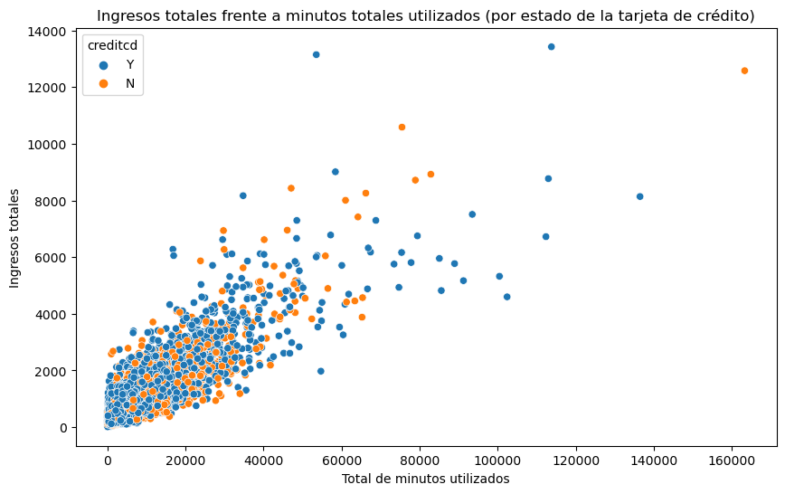

```python
# Gráfico de dispersión con el estado de la tarjeta de crédito
plt.figure(figsize=(10, 6))
sns.scatterplot(x='totmou', y='totrev', hue='creditcd', data=df_clean)
plt.title('Ingresos totales frente a minutos totales utilizados (por estado de la tarjeta de crédito)')
plt.xlabel('Total de minutos utilizados')
plt.ylabel('Ingresos totales')
plt.show()
```

```python
from scipy import stats

# Filtrar los datos por crédito y no crédito
grupo_credito = df_clean[df_clean['creditcd'] == 'Y']
grupo_no_credito = df_clean[df_clean['creditcd'] == 'N']

# Prueba t para la variable 'totmou' (Total de minutos utilizados)
t_stat_mou, p_val_mou = stats.ttest_ind(grupo_credito['totmou'], grupo_no_credito['totmou'], equal_var=False)
print(f"Prueba t para totmou: t-stat = {t_stat_mou}, p-valor = {p_val_mou}")

# Prueba t para la variable 'totrev' (Ingresos totales)
t_stat_rev, p_val_rev = stats.ttest_ind(grupo_credito['totrev'], grupo_no_credito['totrev'], equal_var=False)
print(f"Prueba t para totrev: t-stat = {t_stat_rev}, p-valor = {p_val_rev}")
```

```
Prueba t para totmou: t-stat = -4.549153581030151, p-valor = 5.493978536661206e-06
Prueba t para totrev: t-stat = 0.48659823177010875, p-valor = 0.6265617534374768
```

**Interpretación:** Prueba t para "Total de minutos utilizados" (totmou):

- t-stat: -4.549
- p-valor: 5.49e-06 (0.00000549)

Este p-valor es mucho menor que 0.05, lo que indica que sí existe una diferencia significativa en el total de minutos utilizados entre los grupos de personas que tienen crédito y las que no lo tienen. Dado que el valor t es negativo, las personas sin crédito (creditcd = 'N') tienden a utilizar más minutos que las personas con crédito (creditcd = 'Y').

Prueba t para "Ingresos totales" (totrev):

- t-stat: 0.487
- p-valor: 0.626

Este p-valor es mucho mayor que 0.05, lo que indica que no hay una diferencia significativa en los ingresos totales entre las personas que tienen crédito y las que no lo tienen. Por lo tanto, en este caso, el hecho de tener crédito no parece afectar los ingresos totales.

**Conclusión:**

- Total de minutos utilizados (totmou): El hecho de tener crédito sí afecta esta variable, ya que hay una diferencia significativa entre los grupos, Las personas con tarjeta de crédito podrían tener un mejor control sobre su uso de servicios o estar usando otros métodos para realizar transacciones, evitando acumular tantos minutos.
- Ingresos totales (totrev): El hecho de tener crédito no afecta esta variable, ya que no hay una diferencia significativa entre los grupos.

```python
# Calcular la correlación entre totmou y totrev
correlation = df_clean['totmou'].corr(df_clean['totrev'])
print(f"Correlación entre el total de minutos utilizados y el total de ingresos: {correlation:.4f}")
```

```
Correlación entre el total de minutos utilizados y el total de ingresos: 0.8353
```

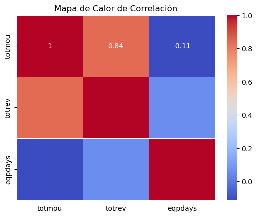

```python
# Calcular la matriz de correlación solo para las columnas numéricas
correlation_matrix = df_clean[['totmou', 'totrev', 'eqpdays']].corr()

# Crear un mapa de calor para la matriz de correlación
sns.heatmap(correlation_matrix, annot=True, cmap='coolwarm', linewidths=0.5)
plt.title('Mapa de Calor de Correlación')
plt.show()
```

```python
# Agrupar por estado de tarjeta de crédito y calcular totmou y totrev medios
grouped = df_clean.groupby('creditcd')[['totmou', 'totrev']].mean()
print("\
Promedio total de minutos utilizados e ingresos totales por estado de la tarjeta de crédito:")
print(grouped)
```

```
Promedio total de minutos utilizados e ingresos totales por estado de la tarjeta de crédito:
               totmou       totrev
creditcd
N         8288.588805  1035.948303
Y         7432.629588  1045.155534
```

```python
A = df_clean[['totmou']] # minutos totales
b = df_clean[['totrev']] # ingresos totales
```

```python
# Modelo de regresión lineal
linear_reg = LinearRegression()

# Ajuste modelo con los datos
linear_reg.fit(A, b)
```

```
LinearRegression()
```

```python
r_squared = linear_reg.score(A, b)
print(f"Coeficiente de determinación R²: {r_squared}")

# Obtener el intercepto y el coeficiente de la regresión
intercept = linear_reg.intercept_
coef = linear_reg.coef_[0]
print(f"Intercepto: {intercept}")
print(f"Coeficiente de la regresión: {coef}")
```

```
Coeficiente de determinación R²: 0.6976905303930583
Intercepto: [405.44087766]
Coeficiente de la regresión: [0.08273181]
```

**Coeficiente de determinación R²:**  
El valor de R² es 0.6977. El coeficiente de determinación R² mide qué tan bien los datos se ajustan a la línea de regresión. Un valor de 0.6977 significa que aproximadamente 69.77% de la variación en los ingresos totales (totrev) puede ser explicada por los minutos totales utilizados (totmou). Este es un valor relativamente bueno, lo que indica que existe una relación considerable entre estas dos variables y que los minutos utilizados tienen una influencia significativa en los ingresos totales.

**Intercepto:**  
El intercepto es 405.4408. Esto significa que cuando los minutos utilizados (totmou) son 0, los ingresos totales (totrev) esperados serían aproximadamente 405.44 unidades. Este valor es la "base" de los ingresos totales cuando no se han utilizado minutos, y cualquier cambio en los minutos incrementará los ingresos en función del coeficiente de la regresión.

**Coeficiente de la regresión:**  
El coeficiente de la regresión es 0.0827. Este valor representa el cambio esperado en los ingresos totales (totrev) por cada minuto adicional utilizado (totmou). En otras palabras, por cada minuto adicional utilizado, los ingresos totales aumentan en promedio en 0.0827 unidades.

**Interpretación general:**  
Relación positiva: El coeficiente de la regresión es positivo, lo que indica que hay una relación positiva entre los minutos utilizados y los ingresos totales. A medida que se incrementan los minutos utilizados, los ingresos totales también tienden a aumentar, aunque en una magnitud pequeña (0.0827 unidades por minuto).

**Calidad del ajuste (R²):**  
El 69.77% de la variabilidad en los ingresos totales es explicado por los minutos totales utilizados, lo cual es bastante bueno. Sin embargo, aún queda un 30.23% de la variabilidad en los ingresos que no es explicada por los minutos utilizados, lo que sugiere que puede haber otras variables que también afectan los ingresos y que no se están considerando en este modelo.

**Conclusión:**  
La regresión lineal muestra una relación significativa entre los minutos utilizados y los ingresos totales. Por cada minuto adicional utilizado, los ingresos totales aumentan ligeramente. El modelo tiene un ajuste decente con un R² del 69.77%, lo que sugiere que los minutos utilizados son un buen predictor de los ingresos totales, aunque no son el único factor que influye en ellos.

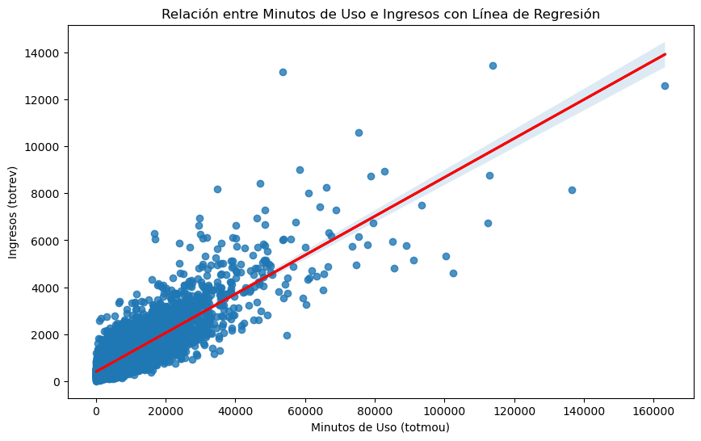

```python
# Crear un gráfico de dispersión con una línea de regresión
b_pred = linear_reg.predict(A)
plt.figure(figsize=(10, 6))
sns.regplot(x='totmou', y='totrev', data=df_clean)
plt.title('Relación entre Minutos de Uso e Ingresos con Línea de Regresión')
plt.plot(A, b_pred, color='red', linewidth=2)
plt.xlabel('Minutos de Uso (totmou)')
plt.ylabel('Ingresos (totrev)')
plt.show()
plt.savefig('minutos_vs_ingresos_regplot.png')
plt.close()
#plt.savefig('regplot_cleaned.png')
plt.close()
```

```python
# plt.figure(figsize=(10, 6))
# sns.catplot(data=df_clean, kind="swarm", x="totrev", y="creditcd")
# plt.show()
```

b. Gráfico de caja para la distribución de 'totmou' por estado de tarjeta de crédito:

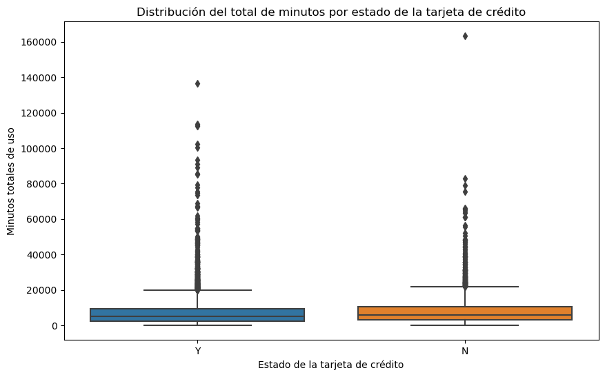

```python
# Crear un diagrama de cajas para mostrar la distribución de «totmou» para diferentes estados de tarjeta de crédito
plt.figure(figsize=(10, 6))
sns.boxplot(x='creditcd', y='totmou', data=df_clean)
plt.title('Distribución del total de minutos por estado de la tarjeta de crédito')
plt.xlabel('Estado de la tarjeta de crédito')
plt.ylabel('Minutos totales de uso')
plt.show()
#plt.savefig('box_plot_cleaned.png')
plt.close()
```

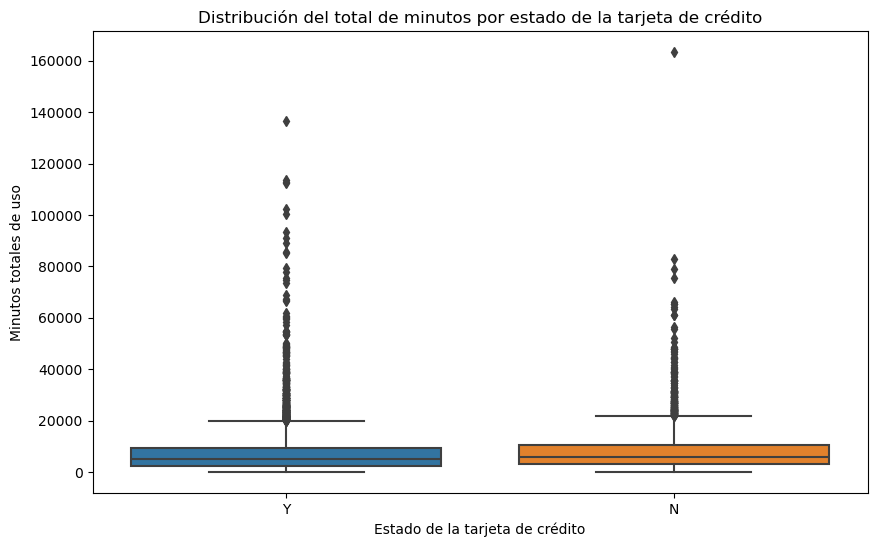

```python
# Crear un diagrama de cajas para mostrar la distribución de «totmou» para diferentes estados de tarjeta de crédito
plt.figure(figsize=(10, 6))
sns.boxplot(x='creditcd', y='totmou', data=df_clean)
plt.title('Distribución del total de minutos por estado de la tarjeta de crédito')
plt.xlabel('Estado de la tarjeta de crédito')
plt.ylabel('Minutos totales de uso')
plt.show()
#plt.savefig('box_plot_cleaned.png')
plt.close()
```

c. Histograma de Días de Equipo (eqpdays)

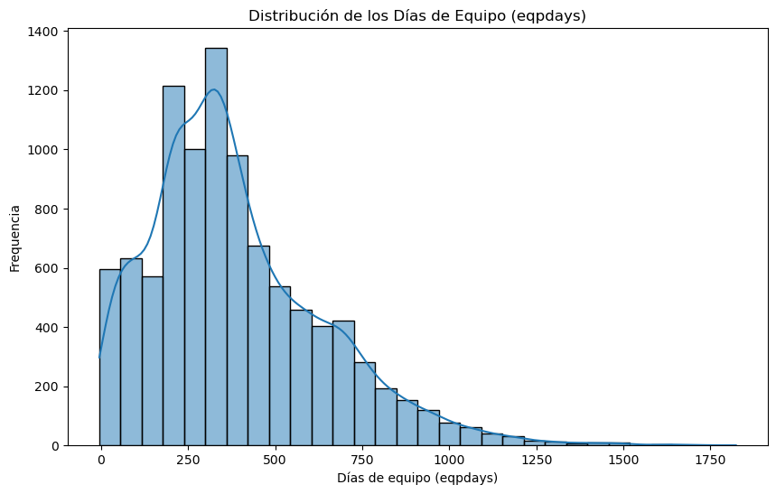

```python
# Crear un histograma de Días de Equipo (eqpdays)
plt.figure(figsize=(10, 6))
sns.histplot(df_clean['eqpdays'], bins=30, kde=True)
plt.title('Distribución de los Días de Equipo (eqpdays)')
plt.xlabel('Días de equipo (eqpdays)')
plt.ylabel('Frequencia')
plt.show()
#plt.savefig('hist_plot_cleaned.png')
plt.close()
```

Este histograma muestra la distribución de los días de equipo. La distribución parece estar sesgada hacia la derecha, con la mayoría de los clientes teniendo menos días de equipo y algunos clientes con valores muy altos.

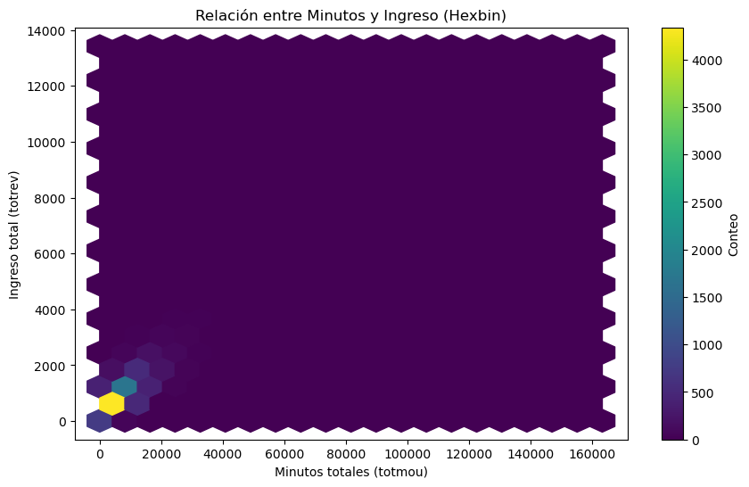

```python
plt.figure(figsize=(10, 6))
plt.hexbin(df_clean['totmou'], df_clean['totrev'], gridsize=20, cmap='viridis')
plt.colorbar(label='Conteo')
plt.title('Relación entre Minutos y Ingreso (Hexbin)')
plt.xlabel('Minutos totales (totmou)')
plt.ylabel('Ingreso total (totrev)')
plt.show()
plt.close()
```

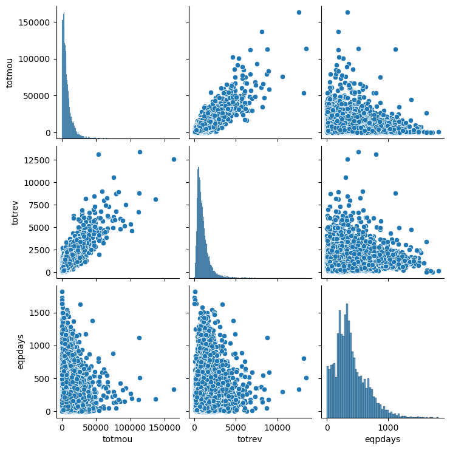

```python
plt.figure(figsize=(10, 6))
sns.pairplot(data=df_clean)
plt.show()
```

```python
# preparación de datos reg logistica
df_clean['creditcd'] = df_clean['creditcd'].apply(lambda x: '1' if x== 'Y' else '0')
```

```python
df_clean.head
```

```
<bound method NDFrame.head of        totmou   totrev creditcd  eqpdays Customer_ID
0      7269.0   906.58        1      371     1082423
1     13552.0  1172.25        0       83     1069232
2      4152.0   577.39        1      675     1031705
3      1863.0   294.26        1      218     1089806
4      4155.0   433.16        0      222     1076695
...       ...      ...      ...      ...         ...
9995   2570.0   484.31        1      611     1027614
9996   2105.0   583.36        1     1243     1098422
9997   3690.0   294.29        1      212     1096497
9998   3333.0   233.08        1      290     1087248
9999   5025.0  1436.49        1     1029     1099003

[9848 rows x 5 columns]>
```

```python
X = df_clean[['totmou','totrev']] # var eje x o variables independientes
y = df_clean['creditcd'] # var eje Y o variable dependiente
```

```python
# Dividir los datos en entrenamiento y prueba (80% entrenamiento, 20% prueba)
X_train, X_test, y_train, y_test = train_test_split(X, y, test_size=0.2, random_state=42)
```

```python
# Crear el modelo de regresión logística
log_reg = LogisticRegression()

# Ajustar el modelo con los datos de entrenamiento
log_reg.fit(X_train, y_train)
```

```
LogisticRegression()
```

```python
y_pred = log_reg.predict(X_test)
```

```python
accuracy = accuracy_score(y_test, y_pred)
print(f"el accuarcy del modelo: {accuracy}")
```

```
el accuarcy del modelo: 0.6888324873096446
```

```python
# Obtener los coeficientes
coef = log_reg.coef_[0]
intercept = log_reg.intercept_

# Interpretar los coeficientes
print(f"Intercepto: {intercept}")
print(f"Coeficientes: {coef}")

# Para una mejor interpretación, se calcula el odds ratio
odds_ratio = np.exp(coef)
print(f"Odds Ratios: {odds_ratio}")
```

```
Intercepto: [2.39779471e-06]
Coeficientes: [-5.78208025e-05  9.82739141e-04]
Odds Ratios: [0.99994218 1.00098322]
```

**Interpretación**

**Conclusión del análisis:** Total de minutos utilizados (totmou) tiene un impacto muy leve y negativo en la probabilidad de que una persona tenga tarjeta de crédito, pero este impacto es casi insignificante dado el tamaño del coeficiente y el odds ratio cercano a 1. Ingresos totales (totrev) tiene un impacto positivo en la probabilidad de que una persona tenga tarjeta de crédito, pero también es un impacto muy pequeño, dado que el odds ratio está apenas por encima de 1.